# Part 1: How have detected cyber threats in Kenya changed?

Phase 5 of the playbook: trends in KE-CIRT/CC quarterly figures, January 2020 to June 2026

```r
library(tidyverse)
library(broom)
library(scales)

source(here::here("R/theme_dataforge.R"))
theme_set(theme_dataforge())
navy <- "#1f3a5f"; accent <- "#d95f02"; grey <- "#b8bec6"
fig_dir <- here::here("outputs/figures")

big <- label_number(scale_cut = cut_short_scale(), accuracy = 0.1)
pct <- function(x, d = 0) paste0(format(round(x, d), nsmall = d, big.mark = ","), "%")
qlabel <- function(d) paste0(c("Jan-Mar", "Apr-Jun", "Jul-Sep", "Oct-Dec")[(month(d) - 1) %/% 3 + 1], " ", year(d))

# Built by scripts/07_extract_ca_figures.R and scripts/08_build_ca_quarterly.R
ca     <- read_csv(here::here("data/processed/ca_quarterly.csv"), show_col_types = FALSE)
totals <- read_csv(here::here("data/processed/ca_totals.csv"), show_col_types = FALSE)
```

**Words used in this notebook.** The Communications Authority counts *detected threat events*: mostly scans and attempts that were blocked. They are not attacks that succeeded and not breaches. “Rose” and “fell” describe the counts; nothing here says what caused them.

## 1. What data we have

```r
totals |>
  summarise(quarters = n(),
            first = qlabel(min(period_start)), last = qlabel(max(period_start)),
            with_categories = sum(has_categories),
            totals_only = sum(!has_categories))
```

```
# A tibble: 1 × 5
  quarters first        last         with_categories totals_only
     <int> <chr>        <chr>                  <int>       <int>
1       26 Jan-Mar 2020 Apr-Jun 2026              21           5
```

All 26 quarters from January 2020 to June 2026 have a total. Of these:

- **21 quarters have a breakdown by category.** The first 10 were typed in by hand and double-checked. The rest were read from the report text by `scripts/07_extract_ca_figures.R`, which checks that every figure appears on its recorded page and that the categories add up to the printed total.
- **5 quarters (April 2022 to June 2023) have totals only.** Those reports show categories in charts without numbers.
- **The category names changed in July 2023.** “System vulnerabilities” became “System Attacks”, and Brute force and Mobile application attacks were added. `docs/ca_category_map.csv` lines the names up, and `docs/decisions.md` explains each merge.

## 2. Total detected events per quarter

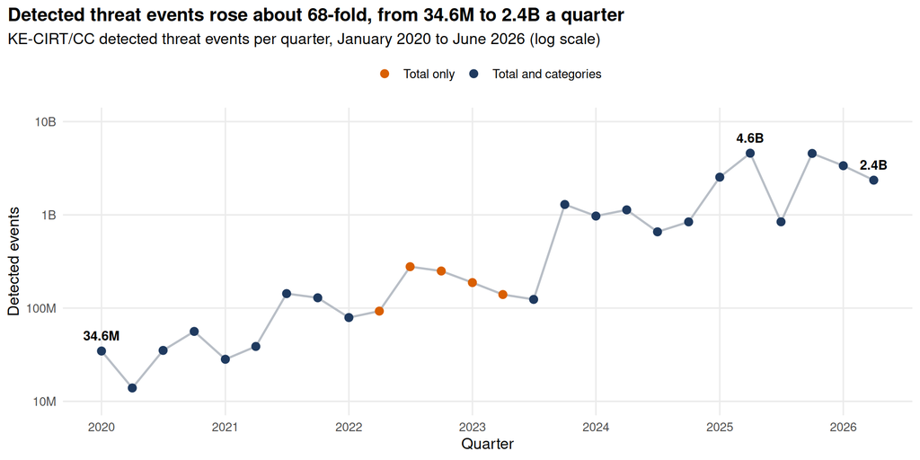

```r
first_q <- totals |> slice_min(period_start)
last_q  <- totals |> slice_max(period_start)
peak    <- totals |> slice_max(reported_total)
growth_x <- last_q$reported_total / first_q$reported_total

p0 <- ggplot(totals, aes(period_start, reported_total)) +
  geom_line(colour = grey, linewidth = 0.8) +
  geom_point(aes(colour = has_categories), size = 2.6) +
  geom_text(data = bind_rows(first_q, peak, last_q),
            aes(label = big(reported_total)), vjust = -1.1, size = 3.6, fontface = "bold") +
  scale_y_log10(labels = label_number(scale_cut = cut_short_scale()),
                breaks = c(1e7, 1e8, 1e9, 1e10), limits = c(1e7, 1e10)) +
  scale_x_date(date_breaks = "1 year", date_labels = "%Y") +
  scale_colour_manual(values = c(`TRUE` = navy, `FALSE` = accent),
                      labels = c(`TRUE` = "Total and categories", `FALSE` = "Total only")) +
  labs(title = paste0("Detected threat events rose about ", round(growth_x), "-fold, from ",
                      big(first_q$reported_total), " to ", big(last_q$reported_total), " a quarter"),
       subtitle = "KE-CIRT/CC detected threat events per quarter, January 2020 to June 2026 (log scale)",
       x = "Quarter", y = "Detected events", colour = NULL)
p0
```

```r
ggsave(file.path(fig_dir, "p1_totals.png"), p0, width = 10, height = 5, dpi = 300, bg = "white")
```

The scale is logarithmic: each gridline is ten times the one below. Detected events went from 34.6M in Jan-Mar 2020 to 2.4B in Apr-Jun 2026, and peaked at 4.6B in Apr-Jun 2025. The series is jumpy: it more than tripled in some quarters and fell by more than three-quarters in others.

## 3. Each category over time (5.1 and 5.2)

```r
by_cat <- ca |>
  group_by(category_std, period_start) |>
  summarise(events = sum(events), .groups = "drop") |>
  complete(category_std, period_start = totals$period_start) |>   # missing quarters show as gaps
  arrange(category_std, period_start)

by_cat |> group_by(category_std) |>
  summarise(quarters_with_data = sum(!is.na(events)),
            first = qlabel(min(period_start[!is.na(events)])),
            last = qlabel(max(period_start[!is.na(events)])))
```

```
# A tibble: 6 × 4
  category_std               quarters_with_data first        last
  <chr>                                   <int> <chr>        <chr>
1 Brute force                                12 Jul-Sep 2023 Apr-Jun 2026
2 DDoS and botnets                           19 Jan-Mar 2020 Apr-Jun 2026
3 Malware                                    21 Jan-Mar 2020 Apr-Jun 2026
4 Mobile application attacks                 12 Jul-Sep 2023 Apr-Jun 2026
5 System attacks                             21 Jan-Mar 2020 Apr-Jun 2026
6 Web application attacks                    21 Jan-Mar 2020 Apr-Jun 2026
```

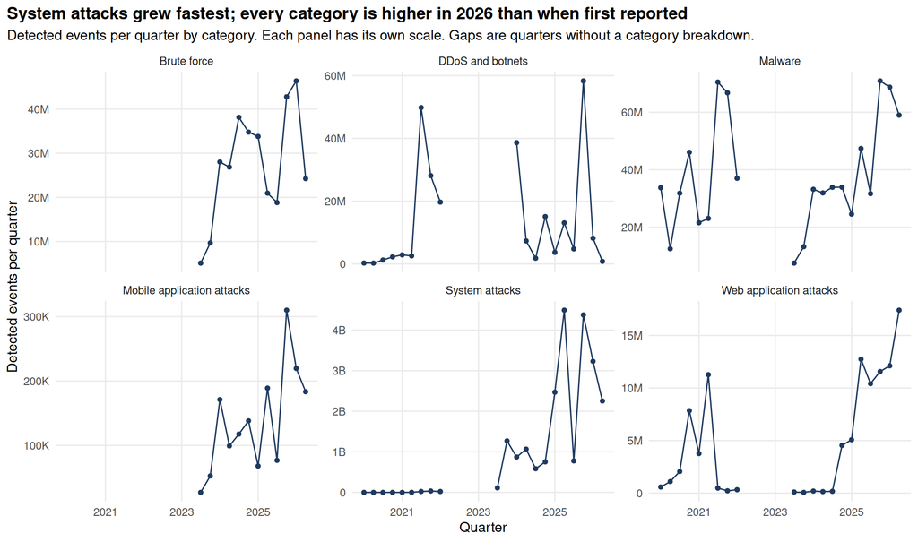

```r
p1 <- ggplot(by_cat, aes(period_start, events)) +
  geom_line(colour = navy) +
  geom_point(colour = navy, size = 1.4) +
  facet_wrap(~ category_std, scales = "free_y") +
  scale_y_continuous(labels = label_number(scale_cut = cut_short_scale())) +
  scale_x_date(date_breaks = "2 years", date_labels = "%Y") +
  labs(title = "System attacks grew fastest; every category is higher in 2026 than when first reported",
       subtitle = "Detected events per quarter by category. Each panel has its own scale. Gaps are quarters without a category breakdown.",
       x = "Quarter", y = "Detected events per quarter")
p1
```

```r
ggsave(file.path(fig_dir, "p1_categories.png"), p1, width = 11, height = 6.5, dpi = 300, bg = "white")
```

## 4. Quarter-on-quarter and year-on-year change (5.3)

Year-on-year compares the same quarter a year apart, so seasonal patterns cancel out. It is the main measure; quarter-on-quarter shows the jumps.

```r
totals_change <- totals |>
  arrange(period_start) |>
  mutate(qoq_pct = 100 * (reported_total / lag(reported_total) - 1),
         yoy_pct = 100 * (reported_total / lag(reported_total, 4) - 1))

totals_change |>
  transmute(Quarter = qlabel(period_start), `Detected events` = comma(reported_total),
            `vs previous quarter` = pct(qoq_pct), `vs same quarter last year` = pct(yoy_pct)) |>
  knitr::kable()
```

| Quarter | Detected events | vs previous quarter | vs same quarter last year |
| --- | --- | --- | --- |
| Jan-Mar 2020 | 34,644,531 | NA% | NA% |
| Apr-Jun 2020 | 13,909,069 | -60% | NA% |
| Jul-Sep 2020 | 35,173,937 | 153% | NA% |
| Oct-Dec 2020 | 56,206,097 | 60% | NA% |
| Jan-Mar 2021 | 28,247,819 | -50% | -18% |
| Apr-Jun 2021 | 38,776,699 | 37% | 179% |
| Jul-Sep 2021 | 143,040,599 | 269% | 307% |
| Oct-Dec 2021 | 129,001,520 | -10% | 130% |
| Jan-Mar 2022 | 79,175,429 | -39% | 180% |
| Apr-Jun 2022 | 92,838,258 | 17% | 139% |
| Jul-Sep 2022 | 278,030,354 | 199% | 94% |
| Oct-Dec 2022 | 249,991,852 | -10% | 94% |
| Jan-Mar 2023 | 187,757,659 | -25% | 137% |
| Apr-Jun 2023 | 139,775,123 | -26% | 51% |
| Jul-Sep 2023 | 123,899,936 | -11% | -55% |
| Oct-Dec 2023 | 1,292,285,408 | 943% | 417% |
| Jan-Mar 2024 | 971,440,345 | -25% | 417% |
| Apr-Jun 2024 | 1,131,696,878 | 16% | 710% |
| Jul-Sep 2024 | 657,843,715 | -42% | 431% |
| Oct-Dec 2024 | 840,921,998 | 28% | -35% |
| Jan-Mar 2025 | 2,538,283,798 | 202% | 161% |
| Apr-Jun 2025 | 4,586,682,277 | 81% | 305% |
| Jul-Sep 2025 | 842,320,667 | -82% | 28% |
| Oct-Dec 2025 | 4,559,229,985 | 441% | 442% |
| Jan-Mar 2026 | 3,367,113,840 | -26% | 33% |
| Apr-Jun 2026 | 2,355,938,192 | -30% | -49% |

```r
cat_change <- by_cat |>
  group_by(category_std) |>
  mutate(qoq_pct = 100 * (events / lag(events) - 1),
         yoy_pct = 100 * (events / lag(events, 4) - 1)) |>
  ungroup()

latest <- max(cat_change$period_start)
cat_change |>
  filter(period_start == latest) |>
  transmute(Category = category_std, `Detected events` = comma(events),
            `vs same quarter last year` = pct(yoy_pct)) |>
  arrange(desc(`Detected events`)) |>
  knitr::kable(caption = paste("Year-on-year change by category,", qlabel(latest)))
```

Year-on-year change by category, Apr-Jun 2026

| Category | Detected events | vs same quarter last year |
| --- | --- | --- |
| DDoS and botnets | 819,325 | -94% |
| Malware | 58,997,257 | 24% |
| Brute force | 24,243,919 | 16% |
| System attacks | 2,254,287,819 | -50% |
| Mobile application attacks | 183,377 | -3% |
| Web application attacks | 17,406,495 | 37% |

```r
yoy_up <- totals_change |> filter(!is.na(yoy_pct)) |> summarise(up = sum(yoy_pct > 0), n = n())
```

Of the 22 quarters that can be compared with the same quarter a year earlier, 18 were higher.

## 5. What share each category takes (5.4)

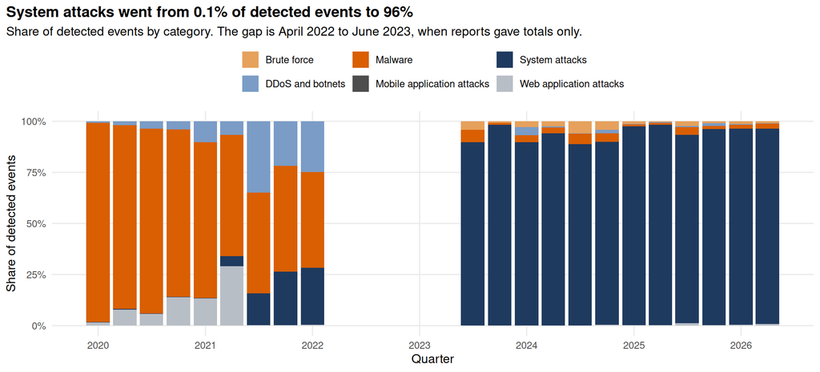

```r
shares <- by_cat |>
  filter(!is.na(events)) |>
  group_by(period_start) |>
  mutate(share = events / sum(events)) |>
  ungroup()

cat_colours <- c("System attacks" = navy, "Malware" = accent, "DDoS and botnets" = "#7a9cc6",
                 "Brute force" = "#e6a15c", "Web application attacks" = grey,
                 "Mobile application attacks" = "#4d4d4d")

sys_share <- shares |> filter(category_std == "System attacks")
p2 <- ggplot(shares, aes(period_start, share, fill = category_std)) +
  geom_col(width = 80) +
  scale_fill_manual(values = cat_colours) +
  scale_y_continuous(labels = percent) +
  scale_x_date(date_breaks = "1 year", date_labels = "%Y") +
  labs(title = paste0("System attacks went from ", pct(100 * first(sys_share$share), 1),
                      " of detected events to ", pct(100 * last(sys_share$share)), ""),
       subtitle = "Share of detected events by category. The gap is April 2022 to June 2023, when reports gave totals only.",
       x = "Quarter", y = "Share of detected events", fill = NULL)
p2
```

```r
ggsave(file.path(fig_dir, "p1_shares.png"), p2, width = 11, height = 5, dpi = 300, bg = "white")
```

With system attacks at over 90% of recent quarters, the other categories are invisible. Here is the same chart without them:

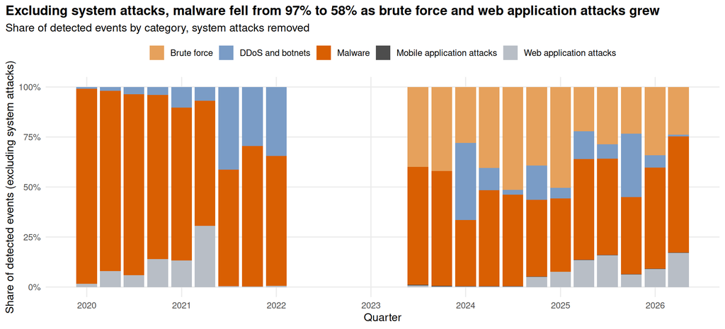

```r
shares_ex <- by_cat |>
  filter(!is.na(events), category_std != "System attacks") |>
  group_by(period_start) |>
  mutate(share = events / sum(events)) |>
  ungroup()
mal_ex <- shares_ex |> filter(category_std == "Malware") |> arrange(period_start)

p2b <- ggplot(shares_ex, aes(period_start, share, fill = category_std)) +
  geom_col(width = 80) +
  scale_fill_manual(values = cat_colours) +
  scale_y_continuous(labels = percent) +
  scale_x_date(date_breaks = "1 year", date_labels = "%Y") +
  labs(title = paste0("Excluding system attacks, malware fell from ", pct(100 * first(mal_ex$share)),
                      " to ", pct(100 * last(mal_ex$share)), " as brute force and web application attacks grew"),
       subtitle = "Share of detected events by category, system attacks removed",
       x = "Quarter", y = "Share of detected events (excluding system attacks)", fill = NULL)
p2b
```

```r
ggsave(file.path(fig_dir, "p1_shares_without_system.png"), p2b, width = 11, height = 5, dpi = 300, bg = "white")
```

## 6. Trend per category, with a confidence range (5.5)

For each series we fit a straight line to the log of detected events. The slope becomes average growth per quarter, with a 95% range. If the range includes zero, there is no clear trend.

```r
fit_trend <- function(d) {
  d <- d |> filter(!is.na(events), events > 0) |>
    mutate(t = as.numeric(period_start - min(period_start)) / 91.31)   # time in quarters
  tidy(lm(log(events) ~ t, data = d), conf.int = TRUE) |>
    filter(term == "t") |>
    mutate(quarters = nrow(d))
}

trends <- bind_rows(
  totals |> transmute(series = "All detected events", period_start, events = reported_total) |>
    group_by(series) |> group_modify(~ fit_trend(.x)),
  by_cat |> rename(series = category_std) |> group_by(series) |> group_modify(~ fit_trend(.x))
) |>
  ungroup() |>
  transmute(series, quarters,
            growth_per_qtr = 100 * (exp(estimate) - 1),
            low = 100 * (exp(conf.low) - 1), high = 100 * (exp(conf.high) - 1),
            growth_per_year = 100 * (exp(4 * estimate) - 1),
            verdict = case_when(low > 0 ~ "Clearly rising", high < 0 ~ "Clearly falling", TRUE ~ "No clear trend"))

trends |>
  arrange(desc(growth_per_qtr)) |>
  transmute(Series = series, Quarters = quarters,
            `Average growth per quarter` = pct(growth_per_qtr, 1),
            `95% range` = paste0(pct(low, 1), " to ", pct(high, 1)),
            `Equivalent per year` = pct(growth_per_year),
            Verdict = verdict) |>
  knitr::kable()
```

| Series | Quarters | Average growth per quarter | 95% range | Equivalent per year | Verdict |
| --- | --- | --- | --- | --- | --- |
| System attacks | 21 | 66.0% | 50.8% to 82.6% | 659% | Clearly rising |
| All detected events | 26 | 23.7% | 19.7% to 27.8% | 134% | Clearly rising |
| Mobile application attacks | 12 | 14.0% | 3.4% to 25.7% | 69% | Clearly rising |
| Brute force | 12 | 11.3% | 0.6% to 23.1% | 54% | Clearly rising |
| DDoS and botnets | 19 | 6.9% | -2.0% to 16.5% | 31% | No clear trend |
| Web application attacks | 21 | 6.2% | -4.2% to 17.8% | 27% | No clear trend |
| Malware | 21 | 1.8% | -1.5% to 5.2% | 7% | No clear trend |

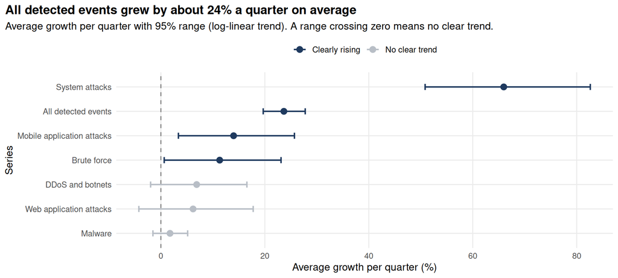

```r
tot_trend <- trends |> filter(series == "All detected events")
p3 <- trends |>
  mutate(series = fct_reorder(series, growth_per_qtr)) |>
  ggplot(aes(growth_per_qtr, series, colour = verdict)) +
  geom_vline(xintercept = 0, linetype = "dashed", colour = "grey50") +
  geom_errorbarh(aes(xmin = low, xmax = high), height = 0.25, linewidth = 0.8) +
  geom_point(size = 3) +
  scale_colour_manual(values = c("Clearly rising" = navy, "No clear trend" = grey, "Clearly falling" = accent)) +
  labs(title = paste0("All detected events grew by about ", pct(tot_trend$growth_per_qtr), " a quarter on average"),
       subtitle = "Average growth per quarter with 95% range (log-linear trend). A range crossing zero means no clear trend.",
       x = "Average growth per quarter (%)", y = "Series", colour = NULL)
p3
```

```r
ggsave(file.path(fig_dir, "p1_trends.png"), p3, width = 10, height = 4.5, dpi = 300, bg = "white")
```

## 7. The biggest jumps and how the Communications Authority explains them (5.6)

```r
jumps <- totals_change |> filter(!is.na(qoq_pct)) |> slice_max(abs(qoq_pct), n = 6)
jumps |>
  transmute(Quarter = qlabel(period_start), `Detected events` = big(reported_total),
            `vs previous quarter` = pct(qoq_pct)) |>
  knitr::kable()
```

| Quarter | Detected events | vs previous quarter |
| --- | --- | --- |
| Oct-Dec 2023 | 1.3B | 943% |
| Oct-Dec 2025 | 4.6B | 441% |
| Jul-Sep 2021 | 143.0M | 269% |
| Jan-Mar 2025 | 2.5B | 202% |
| Jul-Sep 2022 | 278.0M | 199% |
| Jul-Sep 2020 | 35.2M | 153% |

What each report says about its own jump (quoted, with the PDF page):

[output not shown]

The biggest jump, October to December 2023, is partly put down by the Authority itself to **better monitoring**. Changes in how events are detected and counted are therefore a likely part of the story, and growth in these figures should not be read as growth in attacks alone. This is a hypothesis we cannot test with the published totals.

## 8. Findings

```r
sys_tr <- trends |> filter(series == "System attacks")
mal_tr <- trends |> filter(series == "Malware")
yoy_last <- totals_change |> slice_max(period_start)
```

1. Detected threat events rose from 34.6M in Jan-Mar 2020 to 2.4B in Apr-Jun 2026, about 68 times higher, peaking at 4.6B in Apr-Jun 2025.
2. On average, detected events grew by 24% a quarter (95% range 20% to 28%), equivalent to about 134% a year. The series is very uneven, with quarterly changes from -82% to 943%.
3. System attacks drove the growth: their share went from 0.1% of detected events in Jan-Mar 2020 to 96% in Apr-Jun 2026, growing by about 66% a quarter on average.
4. Malware was the largest category in 2020 but, excluding system attacks, its share fell from 97% to 58% as brute force and web application attacks grew.
5. The Authority attributes its largest jump (October to December 2023, +943%) partly to better monitoring, so some of the growth reflects detection rather than attacks. All figures are detected events, not breaches.